# ARIMA Models-(Part I)

Week 9 R-lab  
Zhaohu(Jonathan) Fan

07/08/2021

# Data Example

- The data you can find in the `week9_lab9.csv` file is monthly bituminous coal production in the US from January 1952 through December 1959, a total of 96 observations. **Note: The data is seasonally adjusted (i.e., no need to consider seasonality)*.
- For such a data set, we want to build an ARIMA model. Specifically, we will perform data transformation (only if needed), model identification, model selection, diagnostic checking, parameter estimation, and forecast the next two years (24 observations).
- We will follow the logic: (1) data visualization; (2) the identification of the model to be fit together with our rational based upon the appropriate plots and outputs;(3) estimation of the model parameters and interpretation of significance of the parameters; (4) diagnostic checking on residuals and possible revision to your model choice; (5) forecasts for the period in question.

# Step 1: Data Visualization

- The data (Left) is plotted below. We could see that there is no a clear trend.
- Given 96 observations, we may examine $\frac{96}{4}=24$ autocorrelation coefficients.
- The estimated ACF (middle) and Partial ACF (right) for the undifferenced data are plotted below.
- ACF decays exponentially until lag 10, then increases up to lag 24. PACF at lag 1 and lag 2 jump out.

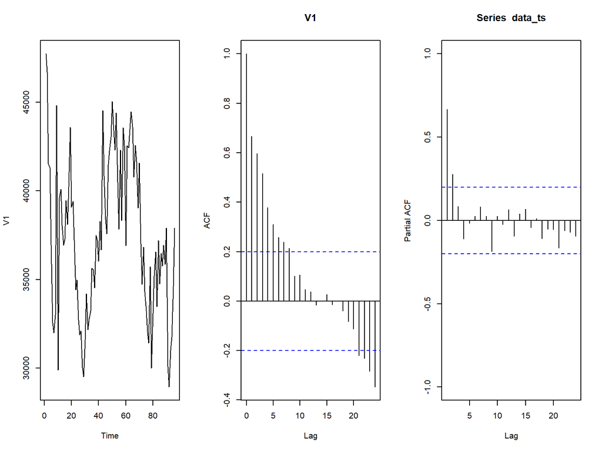

```r
setwd("C:/Users/fanzh/OneDrive - University of Cincinnati/UC_couse/000_Teaching_4090_SS21/Labs/Week9")
## Step 1: Read In Data / Time Series
data<-read.csv("week9_lab9.csv", header=FALSE)
data_ts=ts(data)
#autoplot(data_ts)
# step 2:  ACF and PACF
par(mfrow=c(1,3))
plot.ts(data_ts)
acf(data_ts,lag.max=24)
pacf(data_ts,ylim=c(-1,1),lag.max=24)
```

# Step 2: Model Identification

- We use the Augmented Dickey-Fuller test (ADF) to determine its stationarity.
- The null hypothesis for the test is that the data is non-stationary.
- A p-value of ADF (0.3516) is greater than 0.05. Hence, we fail to reject the null hypothesis for this test.

```r
library(tseries) # The `adf.test()` from the `tseries` package will do a Augmented Dickey-Fuller test
adf.test(data_ts)
```

```
##
##  Augmented Dickey-Fuller Test
##
## data:  data_ts
## Dickey-Fuller = -2.5442, Lag order = 4, p-value = 0.3516
## alternative hypothesis: stationary
```

# Step 2: Model Identification (cont’d)

- **Taking the difference**
  - We take a first order difference of the time series data and check it with ADF again as follows.
  - A p-value of ADF (0.01) is less than 0.05. Therefore, we reject the null hypothesis and conclude that the data is **stationary**.

```r
library(tidyverse)
data_ts%>% diff() %>% adf.test()
```

```
##
##  Augmented Dickey-Fuller Test
##
## data:  .
## Dickey-Fuller = -5.0982, Lag order = 4, p-value = 0.01
## alternative hypothesis: stationary
```

# Step 2: Model Identification (cont’d)

- The estimated ACF (middle) and Partial ACF (right) for the differenced data are plotted below.
- ACF at lag 1 jumps out.
- In addition, PACF at lag 1 jumps out.

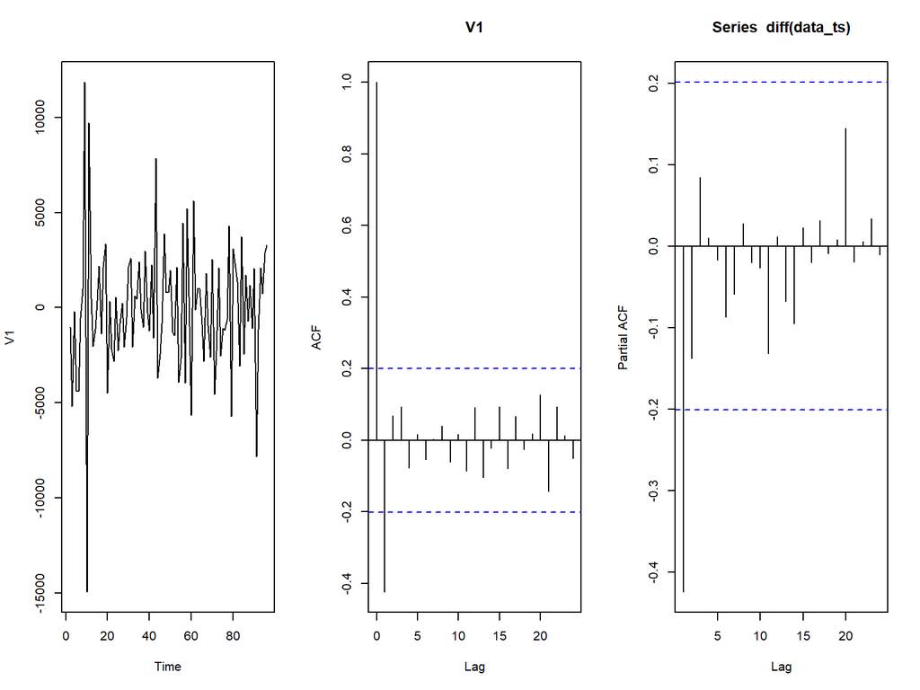

```r
# ACF and PACF
par(mfrow=c(1,3))
plot(diff(data_ts))
acf(diff(data_ts),lag.max=24)
pacf(diff(data_ts),lag.max=24)
```

# Step 2: Model Selection Criteria

- Tsay and Tiao (1984) proposed a practical approach that uses the extended autocorrelation function (EACF) to **specify the order of an ARMA process**. In R, we can implement it using `eacf()` function from the `TSA` R package.
- Next, we begin with a EACF table below. Specifically, we will look for the corners formed by the o’s from the top left.
- Given the ACF and PACF above, this would indicate the following possibilities for our three ARIMA models: **ARIMA(1,1,1)**, **ARIMA(2,1,1)**, and **ARIMA(3,1,1)**.

```r
# step 5:Model selection criteria
library(TSA)
eacf(diff(data_ts))
```

```
## AR/MA
##   0 1 2 3 4 5 6 7 8 9 10 11 12 13
## 0 x o o o o o o o o o o  o  o  o
## 1 x o o o o o o o o o o  o  o  o
## 2 x o o o o o o o o o o  o  o  o
## 3 o o o o o o o o o o o  o  o  o
## 4 o o o o o o o o o o o  o  o  o
## 5 x x o o o o o o o o o  o  o  o
## 6 x x o o o o o o o o o  o  o  o
## 7 x o x o o o o o o o o  o  o  o
```

# Step 2: Model Selection Criteria (cont’d)

- **Bayesian information criterion (BIC)**
- **ARIMA(1,1,1)**

```r
(fit2 <- arima(data_ts, order = c(1, 1, 1)))
```

```
##
## Call:
## arima(x = data_ts, order = c(1, 1, 1))
##
## Coefficients:
##           ar1      ma1
##       -0.2325  -0.2437
## s.e.   0.2018   0.1993
##
## sigma^2 estimated as 9852856:  log likelihood = -899.82,  aic = 1803.64
```

```r
BIC(fit2)
```

```
## [1] 1813.298
```

# Step 2: Model Selection Criteria (cont’d)

- **ARIMA(2,1,1)**

```r
(fit3 <- arima(data_ts, order = c(2, 1, 1)))
```

```
##
## Call:
## arima(x = data_ts, order = c(2, 1, 1))
##
## Coefficients:
##          ar1     ar2      ma1
##       0.5002  0.3400  -1.0000
## s.e.  0.0984  0.1009   0.0462
##
## sigma^2 estimated as 9505347:  log likelihood = -899.07,  aic = 1804.14
```

```r
BIC(fit3)
```

```
## [1] 1816.352
```

# Step 2: Model Selection Criteria (cont’d)

- **ARIMA(3,1,1)**

```r
(fit4 <- arima(data_ts, order = c(3, 1, 1)))
```

```
##
## Call:
## arima(x = data_ts, order = c(3, 1, 1))
##
## Coefficients:
##          ar1     ar2     ar3      ma1
##       0.4674  0.2972  0.1024  -1.0000
## s.e.  0.1040  0.1102  0.1071   0.0476
##
## sigma^2 estimated as 9435882:  log likelihood = -898.61,  aic = 1805.22
```

```r
BIC(fit4)
```

```
## [1] 1819.994
```

- Based on the BIC, we exclude the **ARIMA(3,1,1)**.

# Step 3: Parameter Estimation

- Our model should have all the parameters are significant.
- **ARIMA(1,1,1)**

```r
### Parameter estimation
library(lmtest)
coeftest(fit2)
```

```
##
## z test of coefficients:
##
##     Estimate Std. Error z value Pr(>|z|)
## ar1 -0.23249    0.20176 -1.1524   0.2492
## ma1 -0.24366    0.19927 -1.2228   0.2214
```

# Step 3: Parameter Estimation (cont’d)

- **ARIMA(2,1,1)**

```r
coeftest(fit3)
```

```
##
## z test of coefficients:
##
##      Estimate Std. Error  z value  Pr(>|z|)
## ar1  0.500171   0.098355   5.0854 3.669e-07 ***
## ar2  0.340031   0.100884   3.3705 0.0007503 ***
## ma1 -0.999986   0.046176 -21.6558 < 2.2e-16 ***
## ---
## Signif. codes:  0 '***' 0.001 '**' 0.01 '*' 0.05 '.' 0.1 ' ' 1
```

- Hence, we select our final forecasting model: **ARIMA(2,1,1)**.

# Step 4: Diagnostic Check

- **ARIMA(2,1,1)**
- The residual ACF and PACF all look fine.

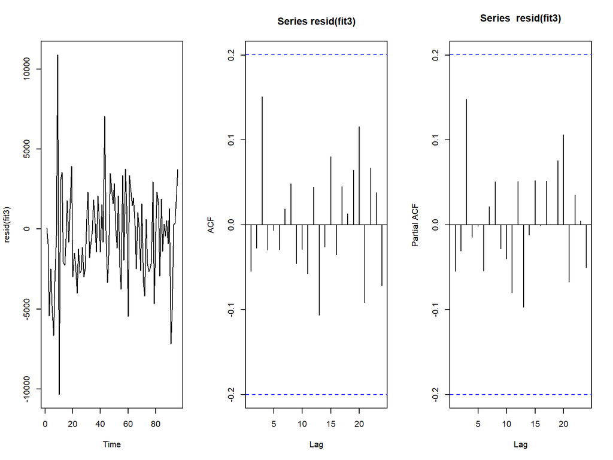

```r
# ACF and PACF
par(mfrow=c(1,3))
plot(resid(fit3))
acf(resid(fit3),lag.max=24)
pacf(resid(fit3),lag.max=24)
```

# Step 4: Diagnostic Check (cont’d)

- We use Ljung-Box test:

```r
Box.test(resid(fit3), lag = 10, type = "Ljung-Box")
```

```
##
##  Box-Ljung test
##
## data:  resid(fit3)
## X-squared = 3.459, df = 10, p-value = 0.9685
```

which fails to reject the null hypothesis.

# Step 4: Diagnostic Check (cont’d)

The output shows that all the parameters are significant. We further look at the residuals. The residual plots below look fine.

```r
library(forecast)
(fit31 <- Arima(data_ts, order = c(2, 1, 1)))
```

```
## Series: data_ts
## ARIMA(2,1,1)
##
## Coefficients:
##          ar1     ar2      ma1
##       0.5002  0.3400  -1.0000
## s.e.  0.0984  0.1009   0.0462
##
## sigma^2 estimated as 9815329:  log likelihood=-899.07
## AIC=1806.14   AICc=1806.58   BIC=1816.35
```

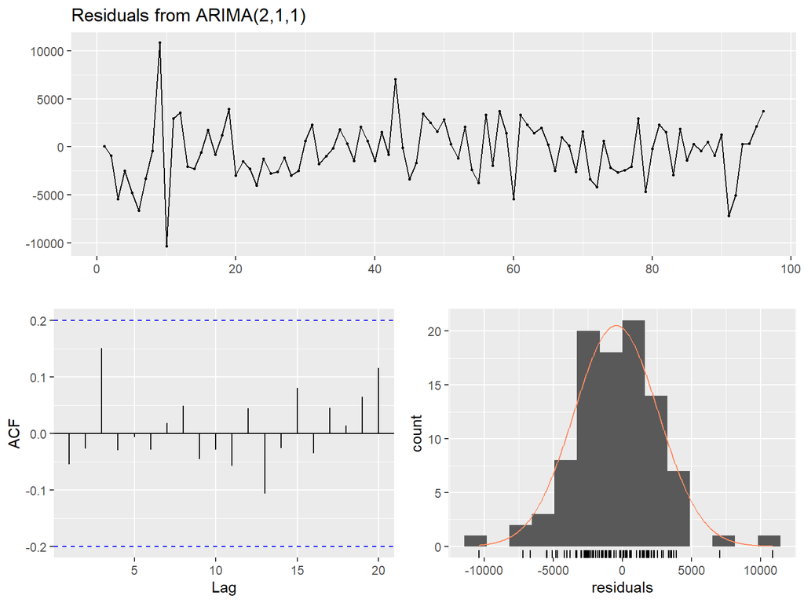

```
##
##  Ljung-Box test
##
## data:  Residuals from ARIMA(2,1,1)
## Q* = 3.459, df = 7, p-value = 0.8395
##
## Model df: 3.   Total lags used: 10
```

```r
checkresiduals(fit31)
```

# Step 4: Diagnostic Check (cont’d)

```r
coeftest(fit31)
```

```
##
## z test of coefficients:
##
##      Estimate Std. Error  z value  Pr(>|z|)
## ar1  0.500171   0.098355   5.0854 3.669e-07 ***
## ar2  0.340031   0.100884   3.3705 0.0007503 ***
## ma1 -0.999986   0.046176 -21.6558 < 2.2e-16 ***
## ---
## Signif. codes:  0 '***' 0.001 '**' 0.01 '*' 0.05 '.' 0.1 ' ' 1
```

- Hence, our final model is the ARIMA(2,1,1):$(1-B)y_t=0.50y_{t-1}+0.34y_{t-2}$-$\varepsilon_{t-1}$+$\varepsilon_{t}$, where $\varepsilon_t\sim(0, \sigma^2)$.
- Note:
  - Autoregressive Moving Average models **(ARMA)**:
    - $y_{t}=c+\phi_{1}y_{t-1}+\cdots+\phi_{p}y_{t-p}+\theta_{1}\varepsilon_{t-1}+\cdots+\theta_{q}\varepsilon_{t -q}+\varepsilon_{t}$, where $\varepsilon_t$ is white noise.
  - Autoregressive Integrated Moving Average models **(ARIMA)**:
    - Combine ARMA model with **differencing**.
    - $(1-B)^d y_t$ follows an ARMA model.
    - A first difference can be written as $y'_{t} = y_{t} - y_{t-1} = y_t - By_{t} = (1 - B)y_{t}$.

# Step 5: Forecasts for the Next Two Years(24 observations)

- Lastly, we make a forecast for next two years with 80$\%$ and 95$\%$ prediction intervals, respectively, as follows:

```r
library(forecast)
fit31%>% forecast(h = 24)
```

```
##     Point Forecast    Lo 80    Hi 80    Lo 95    Hi 95
##  97       36814.73 32781.65 40847.81 30646.67 42982.80
##  98       37389.43 32863.89 41914.98 30468.21 44310.65
##  99       37307.52 32169.02 42446.02 29448.86 45166.18
## 100       37461.96 31965.74 42958.19 29056.21 45867.72
## 101       37511.36 31715.99 43306.72 28648.11 46374.60
## 102       37588.58 31571.97 43605.20 28386.96 46790.20
## 103       37644.00 31451.08 43836.92 28172.75 47115.25
## 104       37697.98 31366.66 44029.30 28015.06 47380.90
## 105       37743.82 31301.66 44185.98 27891.39 47596.25
## 106       37785.10 31253.93 44316.28 27796.53 47773.67
## 107       37821.34 31218.05 44424.63 27722.48 47920.20
## 108       37853.50 31191.49 44515.51 27664.84 48042.17
## 109       37881.91 31171.80 44592.02 27619.68 48144.14
## 110       37907.06 31157.35 44656.77 27584.26 48229.85
## 111       37929.29 31146.82 44711.77 27556.39 48302.19
## 112       37948.96 31139.25 44758.68 27534.41 48363.52
## 113       37966.36 31133.91 44798.82 27517.02 48415.71
## 114       37981.76 31130.22 44833.29 27503.24 48460.27
## 115       37995.37 31127.78 44862.96 27492.30 48498.45
## 116       38007.42 31126.25 44888.58 27483.58 48531.26
## 117       38018.07 31125.38 44910.76 27476.61 48559.53
## 118       38027.49 31125.00 44929.99 27471.04 48583.95
## 119       38035.83 31124.95 44946.70 27466.56 48605.10
## 120       38043.20 31125.15 44961.26 27462.95 48623.45
```

# Step 5: Forecasts for the Next Two Years(24 observations) (cont’d)

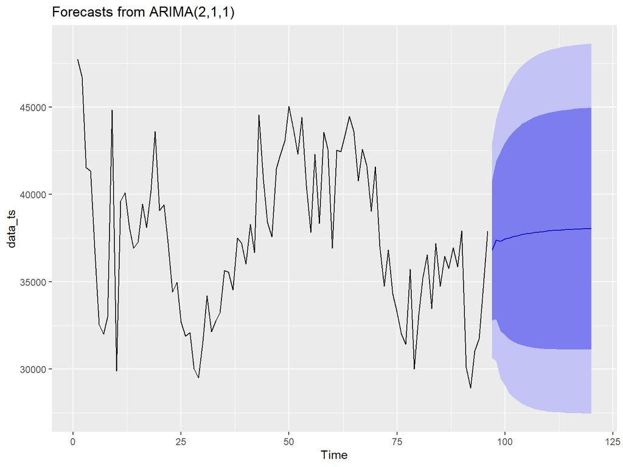

```r
library(forecast)
fit31%>% forecast(h = 24)%>%autoplot()
```